# Analisis Eksplorasi dan Visualisasi Data RNA-seq Hati Tikus

Dataset GEO GSE326527 — Infeksi Murine Norovirus CR6 pada *Mus musculus

Mario Ilham Ramadhan

Rakazaki Putra Hendrawan

Tri Setyo Agus Wibowo

M Haedar Rafli A

19 June 2026

# 1 Pendahuluan

Dataset yang digunakan adalah **GSE326527** dari NCBI GEO, berisi data RNA-seq jaringan hati (*liver*) tikus *Mus musculus* yang terinfeksi **murine norovirus strain CR6** selama 5 hari pasca infeksi (*days post infection*, dpi).

## 1.1 Desain Eksperimen

| Kelompok | Keterangan | Jumlah Sampel |
| --- | --- | --- |
| **STAT1Het** | Heterozygous (kontrol, STAT1 fungsional) | 5 |
| **STAT1KO** | Knockout (STAT1 tidak aktif) | 5 |

**STAT1** (*Signal Transducer and Activator of Transcription 1*) adalah protein kunci dalam jalur pensinyalan interferon. Perbandingan antara kelompok Het dan KO memungkinkan kita mengamati bagaimana hilangnya STAT1 mempengaruhi respons transkriptomik hati terhadap infeksi virus.

## 1.2 Tujuan Analisis

Mengeksplorasi apakah terdapat **perbedaan pola ekspresi gen global** antara kelompok STAT1Het dan STAT1KO melalui pendekatan analisis eksploratif (*Exploratory Data Analysis / EDA*) pada data RNA-seq.

## 1.3 Tahapan Analisis

1. **Data Loading & Cleaning** — memuat data, menangani missing value, dan memfilter gen dengan ekspresi rendah
2. **Eksplorasi Data** — statistik deskriptif per sampel
3. **Visualisasi Distribusi** — boxplot dan histogram sebelum & sesudah transformasi
4. **Transformasi Log2** — untuk menormalkan distribusi skewed pada data count
5. **Analisis Korelasi** — matriks korelasi Pearson antar sampel
6. **Principal Component Analysis (PCA)** — reduksi dimensi untuk melihat pemisahan kelompok
7. **Hierarchical Clustering** — pengelompokan sampel berbasis kemiripan ekspresi
8. **Heatmap Top Variable Genes** — visualisasi 20 gen dengan variansi tertinggi

# 2 Load Data

```r
# Sesuaikan path file CSV dengan lokasi di komputer Anda
data <- read_csv("GSE326527_expression_data.csv")

cat("Dimensi dataset:", nrow(data), "baris x", ncol(data), "kolom\n")
```

```
## Dimensi dataset: 25602 baris x 19 kolom
```

```r
cat("Preview nama kolom:\n")
```

```
## Preview nama kolom:
```

```r
print(colnames(data))
```

```
##  [1] "...1"           "baseMean"       "log2FoldChange" "lfcSE"
##  [5] "stat"           "pvalue"         "padj"           "ensemblID"
##  [9] "symbols"        "liver_1"        "liver_2"        "liver_3"
## [13] "liver_4"        "liver_5"        "liver_6"        "liver_7"
## [17] "liver_9"        "liver_10"       "liver_11"
```

# 3 Data Cleaning

## 3.1 Menangani Gen Tanpa Nama (*Missing Symbols*)

```r
# Pastikan kolom symbols bertipe karakter
data$symbols <- as.character(data$symbols)

# Isi NA pada symbols dengan label "Unknown_N"
data$symbols[is.na(data$symbols)] <- paste0(
  "Unknown_",
  seq_len(sum(is.na(data$symbols)))
)

# Pastikan semua nama gen unik (hindari duplikasi row name)
data$symbols <- make.unique(data$symbols)

cat("Jumlah nama gen yang telah dibuat unik:", length(data$symbols), "\n")
```

```
## Jumlah nama gen yang telah dibuat unik: 25602
```

## 3.2 Seleksi Kolom Sampel Liver

```r
# Jadikan kolom symbols sebagai row name, lalu pilih kolom sampel liver saja
expr <- data %>%
  column_to_rownames("symbols") %>%
  select(starts_with("liver"))

cat("Matriks ekspresi liver:\n")
```

```
## Matriks ekspresi liver:
```

```r
cat("  -", nrow(expr), "gen\n")
```

```
##   - 25602 gen
```

```r
cat("  -", ncol(expr), "sampel\n")
```

```
##   - 10 sampel
```

```r
cat("Nama sampel:", paste(colnames(expr), collapse = ", "), "\n")
```

```
## Nama sampel: liver_1, liver_2, liver_3, liver_4, liver_5, liver_6, liver_7, liver_9, liver_10, liver_11
```

## 3.3 Cek Missing Value

```r
n_missing <- sum(is.na(expr))
cat("Jumlah missing value:", n_missing, "\n")
```

```
## Jumlah missing value: 0
```

```r
if (n_missing == 0) {
  cat("Tidak ada missing value. Data siap diproses.\n")
}
```

```
## Tidak ada missing value. Data siap diproses.
```

## 3.4 Filter Gen Ekspresi Rendah

Gen dengan rata-rata ekspresi ≤ 10 di semua sampel dianggap tidak informatif dan dihapus untuk mengurangi noise.

```r
# Simpan jumlah gen sebelum filter
n_before <- nrow(expr)

# Filter: pertahankan gen dengan rata-rata counts > 10
expr <- expr[rowMeans(expr) > 10, ]

cat("Gen sebelum filter :", n_before, "\n")
```

```
## Gen sebelum filter : 25602
```

```r
cat("Gen setelah filter  :", nrow(expr), "\n")
```

```
## Gen setelah filter  : 14642
```

```r
cat("Gen yang dihapus    :", n_before - nrow(expr), "\n")
```

```
## Gen yang dihapus    : 10960
```

# 4 Eksplorasi Data

## 4.1 Statistik Deskriptif Per Sampel

```r
sample_stats <- data.frame(
  Sample         = colnames(expr),
  Total_Counts   = colSums(expr),
  Mean_Expr      = round(colMeans(expr), 2),
  Var_Expr       = round(apply(expr, 2, var), 2),
  Median_Expr    = round(apply(expr, 2, median), 2),
  Genes_Detected = colSums(expr > 0),
  Detection_Rate = round(colSums(expr > 0) / nrow(expr) * 100, 1)
)

# Tampilkan tabel
sample_stats
```

|  | Sample | Total_Counts | Mean_Expr | Var_Expr | Median_Expr | Genes_Detected | Detection_Rate |
| --- | --- | --- | --- | --- | --- | --- | --- |
| liver_1 | liver_1 | 26607241 | 1817.19 | 654999773 | 301 | 14508 | 99.1 |
| liver_2 | liver_2 | 19722257 | 1346.96 | 267875217 | 225 | 14484 | 98.9 |
| liver_3 | liver_3 | 25866446 | 1766.59 | 471306999 | 308 | 14575 | 99.5 |
| liver_4 | liver_4 | 25378040 | 1733.24 | 363120853 | 303 | 14599 | 99.7 |
| liver_5 | liver_5 | 23240754 | 1587.27 | 316666004 | 292 | 14581 | 99.6 |
| liver_6 | liver_6 | 23234723 | 1586.85 | 429171447 | 242 | 14478 | 98.9 |
| liver_7 | liver_7 | 22746393 | 1553.50 | 396517771 | 255 | 14517 | 99.1 |
| liver_9 | liver_9 | 16919376 | 1155.54 | 151854927 | 210 | 14584 | 99.6 |
| liver_10 | liver_10 | 25718159 | 1756.46 | 329326936 | 327 | 14599 | 99.7 |
| liver_11 | liver_11 | 23956709 | 1636.16 | 519846727 | 264 | 14525 | 99.2 |

> **Interpretasi:** Tabel di atas menunjukkan ringkasan statistik per sampel. *Detection rate* yang tinggi dan konsisten antar sampel mengindikasikan kualitas sekuensing yang baik. Perbedaan nilai *total counts* antar sampel menjadi alasan perlunya transformasi data sebelum analisis lebih lanjut.

# 5 Visualisasi Distribusi Data

## 5.1 Visualisasi Sebelum Transformasi (*Raw Counts*)

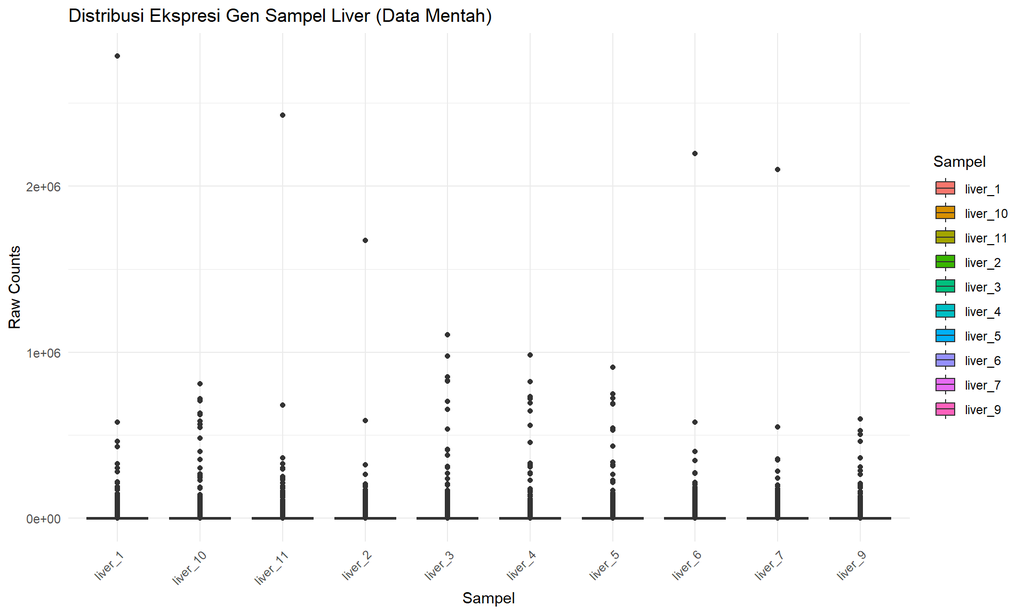

```r
# Ubah ke format long untuk ggplot
expr_long <- expr %>%
  rownames_to_column(var = "Gene") %>%
  pivot_longer(
    cols      = -Gene,
    names_to  = "Sample",
    values_to = "Counts"
  )

# Boxplot raw counts
boxplot_expr_raw <- ggplot(
  expr_long,
  aes(x = Sample, y = Counts + 1, fill = Sample)
) +
  geom_boxplot() +
  theme_minimal() +
  theme(
    axis.text.x = element_text(angle = 45, hjust = 1)
  ) +
  labs(
    title = "Distribusi Ekspresi Gen Sampel Liver (Data Mentah)",
    x = "Sampel",
    y = "Raw Counts",
    fill = "Sampel"
  )

print(boxplot_expr_raw)
```

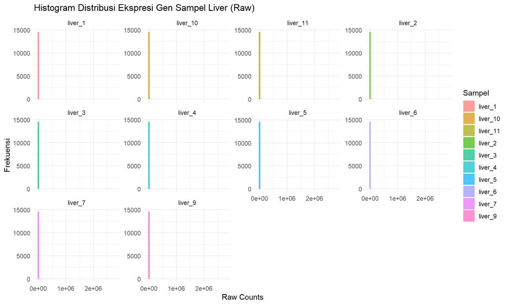

```r
# Histogram raw counts per sampel
histogram_expr_raw <- ggplot(
  expr_long,
  aes(x = Counts + 1, fill = Sample)
) +
  geom_histogram(
    bins = 50,
    alpha = 0.7
  ) +
  facet_wrap(~Sample, scales = "free_y") +
  theme_minimal() +
  labs(
    title = "Histogram Distribusi Ekspresi Gen Sampel Liver (Raw)",
    x = "Raw Counts",
    y = "Frekuensi",
    fill = "Sampel"
  )

print(histogram_expr_raw)
```

> **Interpretasi:** Data mentah RNA-seq bersifat *right-skewed* (condong ke kanan) karena sebagian besar gen memiliki ekspresi rendah sementara sedikit gen memiliki ekspresi sangat tinggi. Kondisi ini membuat perbandingan langsung antar sampel kurang tepat, sehingga diperlukan transformasi.

# 6 Transformasi Log2

Transformasi **log2(x + 1)** diaplikasikan untuk:

- Menstabilkan variansi (*variance stabilization*)
- Mendekati distribusi normal
- Mempermudah interpretasi biologis (selisih 1 unit = 2× lipat ekspresi / *fold change*)

```r
expr_log <- log2(expr + 1)

cat("Statistik ringkas setelah transformasi log2:\n")
```

```
## Statistik ringkas setelah transformasi log2:
```

```r
print(summary(as.vector(as.matrix(expr_log))))
```

```
##    Min. 1st Qu.  Median    Mean 3rd Qu.    Max.
##   0.000   6.087   8.087   7.836   9.539  21.408
```

## 6.1 Visualisasi Setelah Transformasi Log2

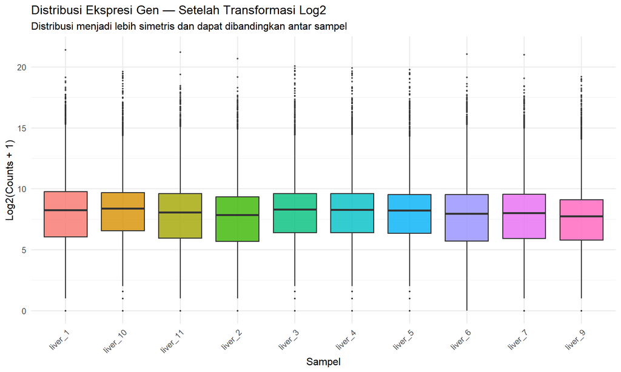

```r
# Ubah ke format long
expr_long_log <- expr_log %>%
  rownames_to_column(var = "Gene") %>%
  pivot_longer(
    cols      = -Gene,
    names_to  = "Sample",
    values_to = "Log_Counts"
  )

# Boxplot setelah transformasi
ggplot(expr_long_log, aes(x = Sample, y = Log_Counts, fill = Sample)) +
  geom_boxplot(outlier.size = 0.5, alpha = 0.8) +
  theme_minimal(base_size = 12) +
  theme(
    axis.text.x     = element_text(angle = 45, hjust = 1),
    legend.position = "none"
  ) +
  labs(
    title    = "Distribusi Ekspresi Gen — Setelah Transformasi Log2",
    subtitle = "Distribusi menjadi lebih simetris dan dapat dibandingkan antar sampel",
    x        = "Sampel",
    y        = "Log2(Counts + 1)"
  )
```

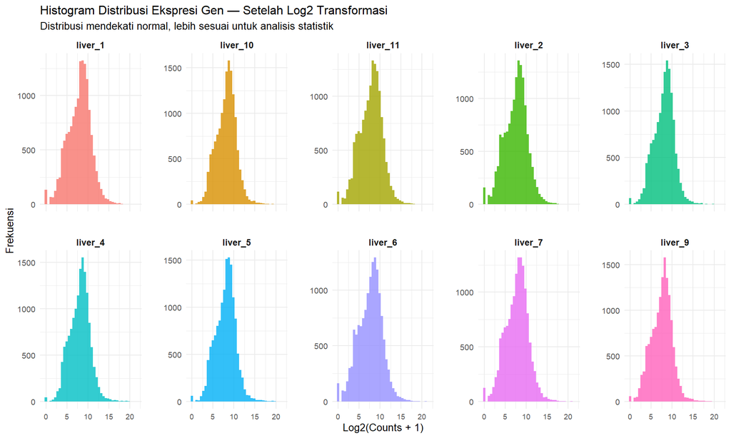

```r
# Histogram setelah transformasi
ggplot(expr_long_log, aes(x = Log_Counts, fill = Sample)) +
  geom_histogram(bins = 40, alpha = 0.8, show.legend = FALSE) +
  facet_wrap(~Sample, scales = "free_y", ncol = 5) +
  theme_minimal(base_size = 10) +
  theme(
    strip.text  = element_text(face = "bold", size = 9),
    panel.spacing = unit(1.5, "lines"),
    axis.text.x = element_text(size = 7)
  ) +
  labs(
    title    = "Histogram Distribusi Ekspresi Gen — Setelah Log2 Transformasi",
    subtitle = "Distribusi mendekati normal, lebih sesuai untuk analisis statistik",
    x        = "Log2(Counts + 1)",
    y        = "Frekuensi"
  )
```

> **Interpretasi:** Setelah transformasi log2, distribusi data menjadi lebih simetris dan mendekati distribusi normal. Hal ini memungkinkan penggunaan metode-metode analisis berbasis asumsi normalitas seperti PCA dan korelasi Pearson.

# 7 Analisis Korelasi Antar Sampel

Korelasi Pearson dihitung pada data yang telah ditransformasi log2. Nilai korelasi tinggi (mendekati 1) antar sampel dalam kelompok yang sama mengindikasikan konsistensi biologis yang baik (*good replicates*).

```r
cor_matrix <- cor(expr_log, method = "pearson")
cat("Matriks korelasi Pearson (dibulatkan 3 desimal):\n")
```

```
## Matriks korelasi Pearson (dibulatkan 3 desimal):
```

```r
print(round(cor_matrix, 3))
```

```
##          liver_1 liver_2 liver_3 liver_4 liver_5 liver_6 liver_7 liver_9
## liver_1    1.000   0.978   0.839   0.878   0.857   0.978   0.974   0.856
## liver_2    0.978   1.000   0.834   0.873   0.856   0.976   0.969   0.853
## liver_3    0.839   0.834   1.000   0.972   0.978   0.828   0.841   0.965
## liver_4    0.878   0.873   0.972   1.000   0.980   0.870   0.877   0.964
## liver_5    0.857   0.856   0.978   0.980   1.000   0.849   0.858   0.965
## liver_6    0.978   0.976   0.828   0.870   0.849   1.000   0.978   0.848
## liver_7    0.974   0.969   0.841   0.877   0.858   0.978   1.000   0.859
## liver_9    0.856   0.853   0.965   0.964   0.965   0.848   0.859   1.000
## liver_10   0.863   0.857   0.966   0.972   0.971   0.856   0.871   0.968
## liver_11   0.975   0.969   0.848   0.881   0.866   0.975   0.982   0.863
##          liver_10 liver_11
## liver_1     0.863    0.975
## liver_2     0.857    0.969
## liver_3     0.966    0.848
## liver_4     0.972    0.881
## liver_5     0.971    0.866
## liver_6     0.856    0.975
## liver_7     0.871    0.982
## liver_9     0.968    0.863
## liver_10    1.000    0.877
## liver_11    0.877    1.000
```

## 7.1 Correlation Heatmap

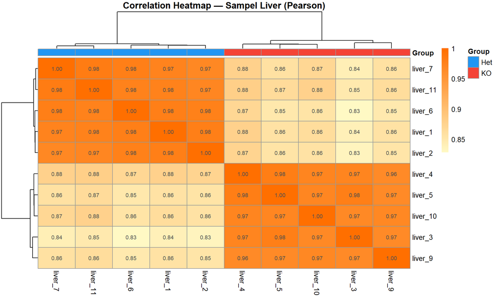

```r
# Tentukan warna anotasi kelompok
group_colors <- list(
  Group = c(Het = "#2196F3", KO = "#F44336")
)

# Anotasi kolom berdasarkan kelompok
annotation_col <- data.frame(
  Group = factor(c("Het", "Het", "KO", "KO", "KO", "Het", "Het", "KO", "KO", "Het"))
)
rownames(annotation_col) <- colnames(expr_log)

pheatmap(
  cor_matrix,
  annotation_col   = annotation_col,
  annotation_colors = group_colors,
  display_numbers  = TRUE,
  number_format    = "%.2f",
  fontsize_number  = 8,
  fontsize         = 10,
  color            = colorRampPalette(c("#FFF9C4", "#FF6F00"))(100),
  main             = "Correlation Heatmap — Sampel Liver (Pearson)"
)
```

> **Interpretasi:** Heatmap korelasi menunjukkan seberapa mirip pola ekspresi global antar sampel. Idealnya, sampel dalam kelompok yang sama (Het–Het atau KO–KO) memiliki korelasi lebih tinggi dibanding antar kelompok. Pola ini menjadi indikator awal adanya perbedaan biologis antara STAT1Het dan STAT1KO.

# 8 Pemilihan Top Variable Genes

Untuk analisis PCA dan clustering, digunakan **20 gen dengan variansi tertinggi** (*top variable genes*). Pendekatan ini memfokuskan analisis pada gen yang paling informatif dalam membedakan sampel.

```r
# Definisi kelompok sampel
group <- factor(c("Het", "Het", "KO", "KO", "KO", "Het", "Het", "KO", "KO", "Het"))

# Hitung variansi per gen
gene_variance <- apply(expr_log, 1, var)

cat("Ringkasan variansi gen:\n")
```

```
## Ringkasan variansi gen:
```

```r
print(summary(gene_variance))
```

```
##      Min.   1st Qu.    Median      Mean   3rd Qu.      Max.
##  0.008377  0.084913  0.184345  0.689424  0.521826 58.309098
```

```r
# Ambil 20 gen dengan variansi tertinggi
top20 <- expr_log[order(gene_variance, decreasing = TRUE)[1:20], ]

cat("Dimensi matriks top 20 gen:", nrow(top20), "gen x", ncol(top20), "sampel\n")
```

```
## Dimensi matriks top 20 gen: 20 gen x 10 sampel
```

```r
cat("Nama gen terpilih:\n")
```

```
## Nama gen terpilih:
```

```r
print(rownames(top20))
```

```
##  [1] "A2m"          "Gm10222"      "Saa2"         "Gm12671"      "Car3"
##  [6] "Lcn2"         "Saa1"         "Cyp2c69"      "Chil3"        "Unknown_6314"
## [11] "Saa3"         "Ngp"          "Ltf"          "S100a8"       "Chil1"
## [16] "Car4"         "Hao2"         "Il1r2"        "Unknown_696"  "S100a9"
```

# 9 Principal Component Analysis (PCA)

PCA adalah teknik reduksi dimensi yang memproyeksikan data berdimensi tinggi ke komponen-komponen utama (*principal components*) yang menangkap variansi terbesar. Analisis ini dilakukan pada level sampel (bukan gen).

```r
# Transpose: baris = sampel, kolom = gen (format yang dibutuhkan prcomp)
pca_data   <- t(top20)
pca_result <- prcomp(pca_data, center = TRUE, scale. = TRUE)

cat("Ringkasan PCA:\n")
```

```
## Ringkasan PCA:
```

```r
print(summary(pca_result))
```

```
## Importance of components:
##                           PC1     PC2     PC3     PC4     PC5     PC6     PC7
## Standard deviation     4.2134 1.22877 0.67399 0.36859 0.25429 0.19881 0.14411
## Proportion of Variance 0.8876 0.07549 0.02271 0.00679 0.00323 0.00198 0.00104
## Cumulative Proportion  0.8876 0.96312 0.98584 0.99263 0.99586 0.99784 0.99888
##                           PC8     PC9      PC10
## Standard deviation     0.1265 0.08040 3.351e-16
## Proportion of Variance 0.0008 0.00032 0.000e+00
## Cumulative Proportion  0.9997 1.00000 1.000e+00
```

## 9.1 Scree Plot — Proporsi Variansi

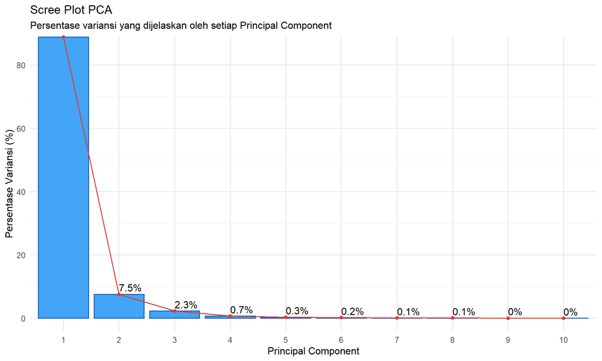

```r
fviz_eig(
  pca_result,
  addlabels = TRUE,
  ylim      = c(0, 85),
  barfill   = "#42A5F5",
  barcolor  = "#1565C0",
  linecolor = "#E53935"
) +
  labs(
    title    = "Scree Plot PCA",
    subtitle = "Persentase variansi yang dijelaskan oleh setiap Principal Component",
    x        = "Principal Component",
    y        = "Persentase Variansi (%)"
  ) +
  theme_minimal(base_size = 12)
```

## 9.2 PCA Score Plot (PC1 vs PC2)

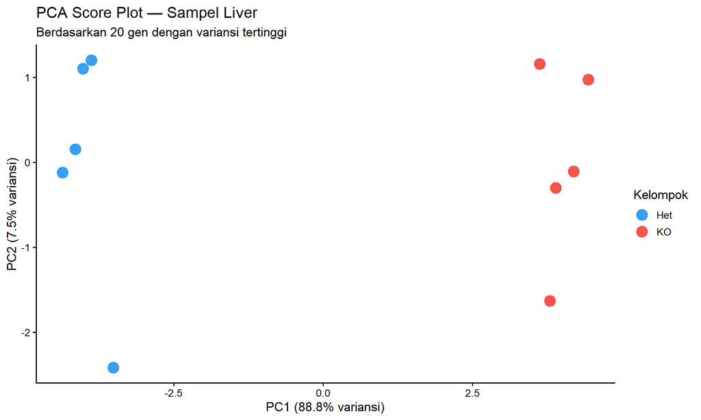

```r
pc_scores        <- as.data.frame(pca_result$x)
pc_scores$Group  <- group

# Hitung persentase variansi untuk label sumbu
pct_var <- round(summary(pca_result)$importance[2, ] * 100, 1)

ggplot(pc_scores, aes(x = PC1, y = PC2, color = Group)) +
  geom_point(size = 5, alpha = 0.9) +
  scale_color_manual(values = c(Het = "#2196F3", KO = "#F44336")) +
  theme_classic(base_size = 13) +
  labs(
    title    = "PCA Score Plot — Sampel Liver",
    subtitle = "Berdasarkan 20 gen dengan variansi tertinggi",
    x        = paste0("PC1 (", pct_var[1], "% variansi)"),
    y        = paste0("PC2 (", pct_var[2], "% variansi)"),
    color    = "Kelompok"
  )
```

## 9.3 PCA dengan Confidence Ellipse (95%)

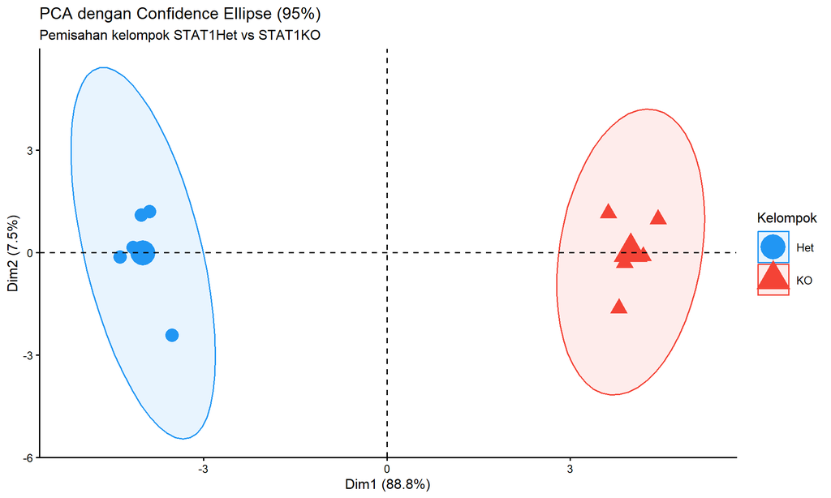

```r
fviz_pca_ind(
  pca_result,
  geom.ind      = "point",
  pointsize     = 5,
  habillage     = group,
  addEllipses   = TRUE,
  ellipse.level = 0.95,
  palette       = c("#2196F3", "#F44336"),
  repel         = TRUE,
  legend.title  = "Kelompok"
) +
  labs(
    title    = "PCA dengan Confidence Ellipse (95%)",
    subtitle = "Pemisahan kelompok STAT1Het vs STAT1KO"
  ) +
  theme_classic(base_size = 12)
```

> **Interpretasi:** Score plot PCA memvisualisasikan posisi setiap sampel dalam ruang dua dimensi (PC1 dan PC2). Jika sampel dari kelompok Het dan KO membentuk klaster yang terpisah, hal ini mengindikasikan adanya **perbedaan pola ekspresi gen yang sistematis** antara kedua kelompok, yang kemungkinan besar dipengaruhi oleh status STAT1. Ellipse 95% mempertegas batas pemisahan antar kelompok secara statistik.

# 10 Hierarchical Clustering

Hierarchical clustering mengelompokkan sampel berdasarkan kemiripan profil ekspresi menggunakan jarak Euclidean dan metode *Ward’s linkage*. Metode Ward meminimalkan total variansi dalam klaster sehingga cocok untuk data genomik.

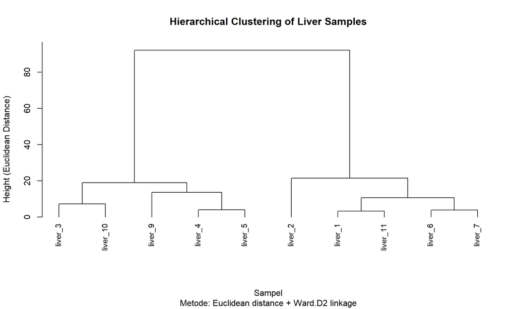

```r
# Hitung matriks jarak antar sampel
distance_matrix <- dist(t(top20), method = "euclidean")

# Bangun dendrogram dengan metode Ward.D2
hc <- hclust(distance_matrix, method = "ward.D2")

# Plot dendrogram
plot(
  hc,
  hang  = -1,
  cex   = 0.9,
  main  = "Hierarchical Clustering of Liver Samples",
  sub   = "Metode: Euclidean distance + Ward.D2 linkage",
  xlab  = "Sampel",
  ylab  = "Height (Euclidean Distance)"
)
```

> **Interpretasi:** Dendrogram menunjukkan hierarki kemiripan antar sampel. Sampel yang bergabung lebih awal (pada *height* yang lebih rendah) memiliki profil ekspresi yang lebih mirip. Pengelompokan yang konsisten dengan label Het dan KO memperkuat temuan dari PCA.

# 11 Heatmap Top 20 Variable Genes

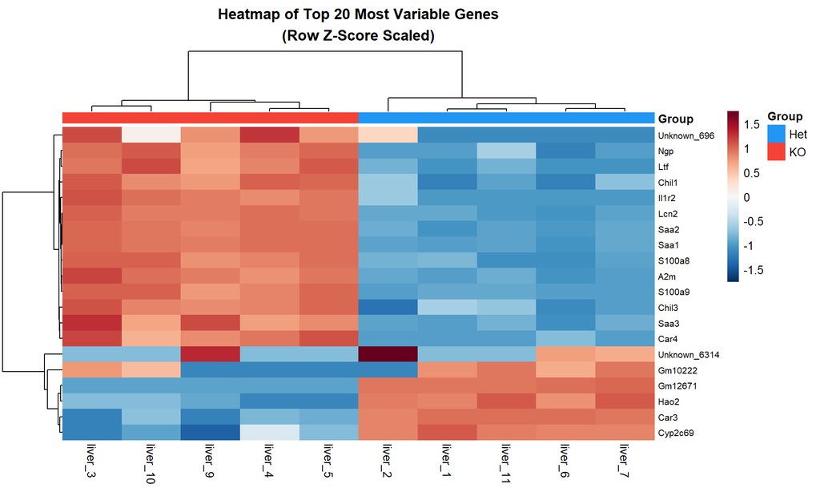

```r
# Anotasi kelompok untuk heatmap
annotation_heatmap <- data.frame(Group = group)
rownames(annotation_heatmap) <- colnames(top20)

# Warna anotasi
ann_colors <- list(
  Group = c(Het = "#2196F3", KO = "#F44336")
)

pheatmap(
  top20,
  scale              = "row",
  annotation_col     = annotation_heatmap,
  annotation_colors  = ann_colors,
  show_rownames      = TRUE,
  show_colnames      = TRUE,
  clustering_method  = "ward.D2",
  color              = colorRampPalette(rev(brewer.pal(11, "RdBu")))(100),
  fontsize_col       = 10,
  fontsize_row       = 8,
  border_color       = NA,
  main               = "Heatmap of Top 20 Most Variable Genes\n(Row Z-Score Scaled)"
)
```

> **Interpretasi:** Heatmap menampilkan pola ekspresi 20 gen paling variatif di seluruh sampel, dengan nilai yang telah di-*scale* per baris (*z-score*) sehingga warna mencerminkan ekspresi relatif (bukan nilai absolut). Warna merah menunjukkan ekspresi tinggi relatif terhadap rata-rata, biru menunjukkan ekspresi rendah. Pola terpisah antara kelompok Het dan KO menunjukkan gen-gen ini berpotensi diregulasi oleh jalur STAT1.

# 12 Ringkasan & Kesimpulan

Analisis eksplorasi data RNA-seq hati tikus *Mus musculus* (GSE326527) menghasilkan temuan sebagai berikut:

| Analisis | Temuan |
| --- | --- |
| **Kualitas Data** | Tidak ada missing value; detection rate konsisten antar sampel |
| **Distribusi** | Data mentah bersifat *right-skewed*; transformasi log2 berhasil menormalkan distribusi |
| **Korelasi** | Korelasi Pearson tinggi dalam kelompok menunjukkan replikasi biologis yang baik |
| **PCA** | PC1 menjelaskan variansi terbesar; terdapat indikasi pemisahan kelompok Het vs KO |
| **Clustering** | Dendrogram mengelompokkan sampel konsisten dengan label kelompok |
| **Heatmap** | 20 gen tervariabel menunjukkan pola ekspresi berbeda antara Het dan KO |

**Kesimpulan umum:** Terdapat **perbedaan pola ekspresi gen global** antara kelompok STAT1Het dan STAT1KO pada jaringan hati tikus yang terinfeksi murine norovirus CR6. Perbedaan ini konsisten teramati di seluruh metode analisis yang digunakan, mengindikasikan peran penting STAT1 dalam memodulasi respons transkriptomik hati terhadap infeksi virus.